# Reproducible Research Assignment 1

George Polzer

March 26, 2016

### Loading and preprocessing the data

1. Load the data (i.e. read.csv())
2. Process/transform the data (if necessary) into a format suitable for your analysis

```r
#Part 1
#Set directory
setwd("C:/Users/Owner/Google Drive/___Coursera/Data Science/Assignments/Completed/Reproducible Research")
#Read data file
data <- read.csv("activity.csv", colClasses = c("integer", "Date","factor"))
#look at the data structure
str(data)
```

```
## 'data.frame':    17568 obs. of  3 variables:
##  $ steps   : int  NA NA NA NA NA NA NA NA NA NA ...
##  $ date    : Date, format: "2012-10-01" "2012-10-01" ...
##  $ interval: Factor w/ 288 levels "0","10","100",..: 1 226 2 73 136 195 198 209 212 223 ...
```

```r
#Part 2
#create a column for month by extracting it from the date column
data$month <- as.numeric(format(data$date, "%m"))
#remove all data with NA values - store the resulting data set in data set titled "complete"
complete <- na.omit(data)
```

### What is mean total number of steps taken per day?

1. Calculate the total number of steps taken per day
2. If you do not understand the difference between a histogram and a barplot, research the difference between them. Make a histogram of the total number of steps taken each day
3. Calculate and report the mean and median of the total number of steps taken per day

```r
#Part 1
#sum daily steps and format date output
daily_steps <- rowsum(complete$steps, format(complete$date, '%Y-%m-%d'))
daily_steps
```

```
##             [,1]
## 2012-10-02   126
## 2012-10-03 11352
## 2012-10-04 12116
## 2012-10-05 13294
## 2012-10-06 15420
## 2012-10-07 11015
## 2012-10-09 12811
## 2012-10-10  9900
## 2012-10-11 10304
## 2012-10-12 17382
## 2012-10-13 12426
## 2012-10-14 15098
## 2012-10-15 10139
## 2012-10-16 15084
## 2012-10-17 13452
## 2012-10-18 10056
## 2012-10-19 11829
## 2012-10-20 10395
## 2012-10-21  8821
## 2012-10-22 13460
## 2012-10-23  8918
## 2012-10-24  8355
## 2012-10-25  2492
## 2012-10-26  6778
## 2012-10-27 10119
## 2012-10-28 11458
## 2012-10-29  5018
## 2012-10-30  9819
## 2012-10-31 15414
## 2012-11-02 10600
## 2012-11-03 10571
## 2012-11-05 10439
## 2012-11-06  8334
## 2012-11-07 12883
## 2012-11-08  3219
## 2012-11-11 12608
## 2012-11-12 10765
## 2012-11-13  7336
## 2012-11-15    41
## 2012-11-16  5441
## 2012-11-17 14339
## 2012-11-18 15110
## 2012-11-19  8841
## 2012-11-20  4472
## 2012-11-21 12787
## 2012-11-22 20427
## 2012-11-23 21194
## 2012-11-24 14478
## 2012-11-25 11834
## 2012-11-26 11162
## 2012-11-27 13646
## 2012-11-28 10183
## 2012-11-29  7047
```

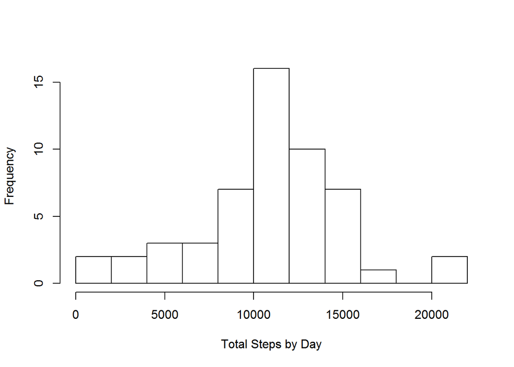

```r
#Part 2
#create and label histogram of daiy totals
hist(daily_steps,
     main=" ",
     breaks=10,
     xlab="Total Steps by Day")
```

```r
#Part 3
#calculate mean and median
mean(daily_steps)
```

```
## [1] 10766.19
```

```r
median(daily_steps)
```

```
## [1] 10765
```

### What is the average daily activity pattern?

1. Make a time series plot (i.e. type = “l”) of the 5-minute interval (x-axis) and the average number of steps taken, averaged across all days (y-axis)
2. Which 5-minute interval, on average across all the days in the dataset, contains the maximum number of steps?

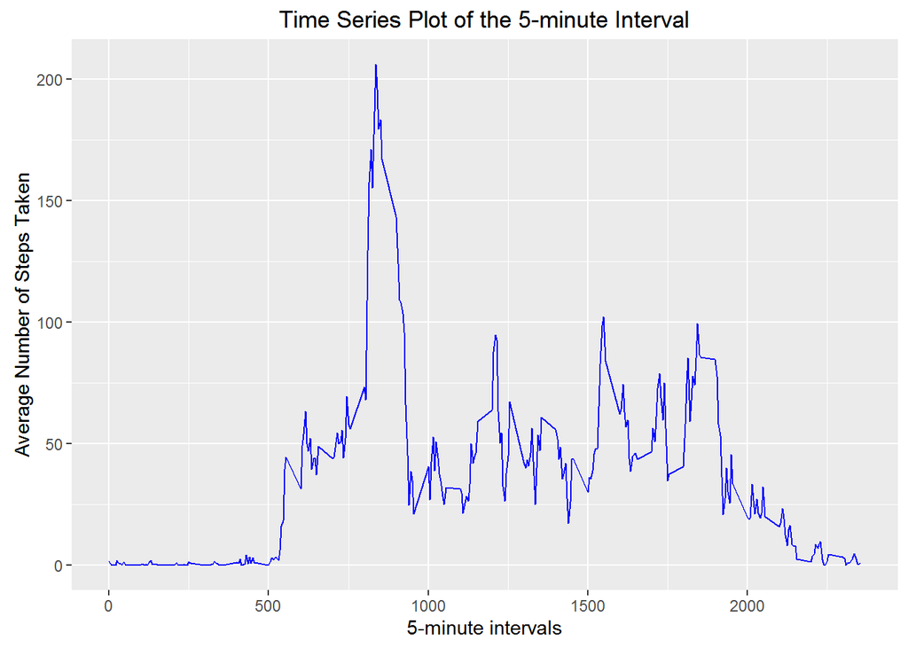

```r
#Part 1
#compute average steps per interval - take mean of steps for every interval in the list
steps_per_interval <- aggregate(complete$steps, list(interval=as.numeric(as.character(complete$interval))),FUN ="mean")
#label the average steps column "Mean_Steps"
names(steps_per_interval)[2] <- "Mean_Steps"
library(ggplot2)
#ploy intervals as x and mean steps as y
ggplot(steps_per_interval, aes(interval, Mean_Steps)) + geom_line(color = "blue", size = 0.4) + labs(title = "Time Series Plot of the 5-minute Interval", x = "5-minute intervals", y = "Average Number of Steps Taken")
```

```r
#Part 2
#find the max interval, then display it
which.max(steps_per_interval$Mean_Steps)
```

```
## [1] 104
```

```r
steps_per_interval[104,]
```

```
##     interval Mean_Steps
## 104      835   206.1698
```

### Imputing missing values

Note that there are a number of days/intervals where there are missing values (coded as NA). The presence of missing days may introduce bias into some calculations or summaries of the data. 1. Calculate and report the total number of missing values in the dataset (i.e. the total number of rows with NAs) 2. Devise a strategy for filling in all of the missing values in the dataset. The strategy does not need to be sophisticated. For example, you could use the mean/median for that day, or the mean for that 5-minute interval, etc. 3. Create a new dataset that is equal to the original dataset but with the missing data filled in. 4. Make a histogram of the total number of steps taken each day and Calculate and report the mean and median total number of steps taken per day. Do these values differ from the estimates from the first part of the assignment? What is the impact of imputing missing data on the estimates of the total daily number of steps?

```r
#Part 1
#show how many rows have NA values
sum(is.na(data))
```

```
## [1] 2304
```

```r
#Part 2 and 3 - replace NA values with the mean steps for that specific interval using a loop
fixed_data <- data #creates copy of original data to edit
#loop finds NA values, and uses the given interval to reference the steps_per_interval data set and grab the mean of that interval to replace the NA with
for (i in 1:nrow(fixed_data)) {
    if (is.na(fixed_data$steps[i])) {
        fixed_data$steps[i] <-
        steps_per_interval[which(fixed_data$interval[i] == steps_per_interval$interval), ]$Mean_Steps
    }
}

head(fixed_data) #displays the first 6 rows of new data
```

```
##       steps       date interval month
## 1 1.7169811 2012-10-01        0    10
## 2 0.3396226 2012-10-01        5    10
## 3 0.1320755 2012-10-01       10    10
## 4 0.1509434 2012-10-01       15    10
## 5 0.0754717 2012-10-01       20    10
## 6 2.0943396 2012-10-01       25    10
```

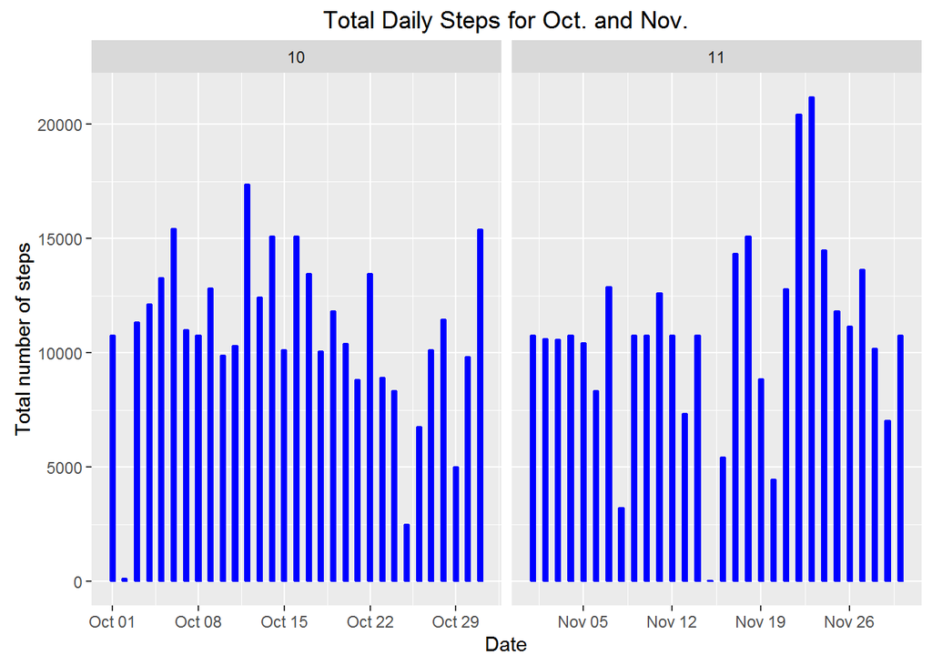

```r
#Part 4
#creates bar graphs showing average daily steps in Oct. and Nov. the facet_grid(. ~ month) forces a seperate graph for each month.
ggplot(fixed_data, aes(date, steps)) + geom_bar(stat = "identity",colour = "blue",fill = "blue",
width = 0.4) + facet_grid(. ~ month, scales = "free") + labs(title = "Total Daily Steps for Oct. and Nov.", x = "Date", y = "Total number of steps")
```

```r
#calculate the sum of steps for each day
FixedTotalSteps <- aggregate(fixed_data$steps,
                           list(Date = fixed_data$date),
                           FUN = "sum")$x
FixedMean <- mean(FixedTotalSteps) #calculates the new mean now that NA values are removed
FixedMean
```

```
## [1] 10766.19
```

```r
FixedMedian <- median(FixedTotalSteps)#calculates the new median now that NA values are removed
FixedMedian
```

```
## [1] 10766.19
```

```r
oldMean <- mean(daily_steps) #saves the old mean (using the NA values)
oldMedian <- median(daily_steps) #saves the old median (using the NA values)
FixedMean - oldMean #compares the old mean and new mean
```

```
## [1] 0
```

```r
FixedMedian - oldMedian #compares the old median and new median - new median is 1.188679 higher
```

```
## [1] 1.188679
```

### Are there differences in activity patterns between weekdays and weekends?

For this part the weekdays() function may be of some help here. Use the dataset with the filled-in missing values for this part. 1. Create a new factor variable in the dataset with two levels - “weekday” and “weekend” indicating whether a given date is a weekday or weekend day. 2. Make a panel plot containing a time series plot (i.e. type = “l”) of the 5-minute interval (x-axis) and the average number of steps taken, averaged across all weekday days or weekend days (y-axis). See the README file in the GitHub repository to see an example of what this plot should look like using simulated data.

```r
#Part 1
#creates new column "weekdays" by pulling the weekday out of the date column
fixed_data$weekdays <- factor(format(fixed_data$date, "%A"))
levels(fixed_data$weekdays)
```

```
## [1] "Friday"    "Monday"    "Saturday"  "Sunday"    "Thursday"  "Tuesday"
## [7] "Wednesday"
```

```r
#changes weekday column from 7 levels (each day) - to 2 levels (weekday or weekend) by grouping them together
levels(fixed_data$weekdays) <- list(weekday = c("Monday", "Tuesday", "Wednesday",  "Thursday", "Friday"),
weekend = c("Saturday", "Sunday"))
levels(fixed_data$weekdays)
```

```
## [1] "weekday" "weekend"
```

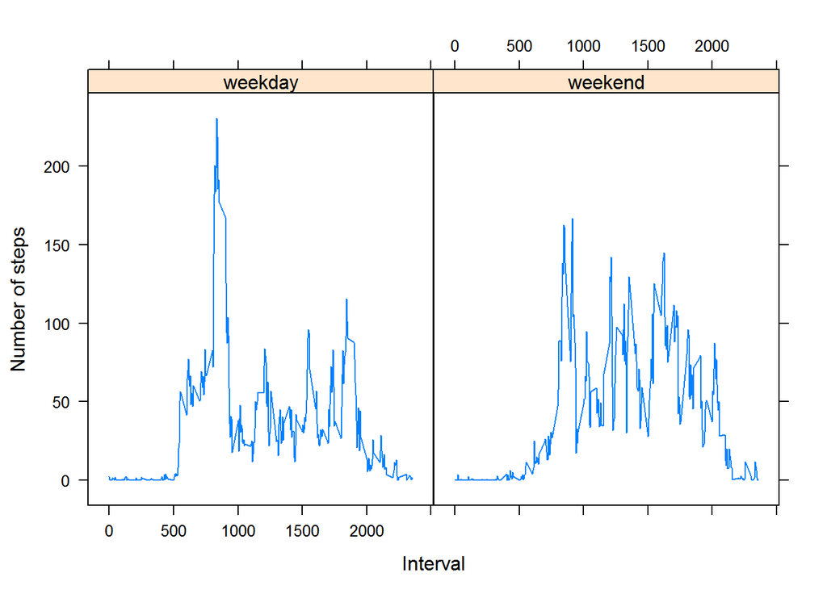

```r
#calculates average steps for the two groups - weekdays and weekends
weekday_avg_steps <- aggregate(fixed_data$steps,
list(interval = as.numeric(as.character(fixed_data$interval)),
weekdays = fixed_data$weekdays),FUN = "mean")
#labels the average steps column "AverageSteps"
names(weekday_avg_steps)[3] <- "AverageSteps"

#Part 2
library(lattice)
#creates plot with AverageSteps as y and Interval as x BY the weekday variable (2 graphs)
xyplot(weekday_avg_steps$AverageSteps ~ weekday_avg_steps$interval | weekday_avg_steps$weekdays,
       layout = c(2, 1), type = "l",
       xlab = "Interval", ylab = "Number of steps")
```